# Part 3 Logistic Regression

Harrison Cradduck, Nick Berry

2025-11-17

# 1 Introduction

**In this phase, we worked with our cleaned loan default data to build a regularized logistic regression model and test how well it performs on the holdout dataset. We used an elastic net regularization approach when training our model on the preprocessed training data.**

# 2 Data Loading

Load in the training and holdout data sets tailored for Part 3 (logistic regression).

```r
# read in .csv training data file
data_train <- readRDS("../data/final_cleaned_train_part3.rds")
```

```r
# read in .csv holdout data file
data_holdout <- readRDS("../data/final_cleaned_holdout_part3.rds")
```

## 2.1 Dummy-coding

Create training and holdout data sets with dummy-coded factor variables. Add in interaction terms for dummy-coded training and holdout data here to resolve issues later.

```r
# set response variable
response <- "loan_default"

# set predictor variables
predictor_cols <- setdiff(names(data_train), response)

# create dummy variables for all factor columns in data_train
data_train_dummy <- fastDummies::dummy_cols(
  data_train[, predictor_cols],
  remove_first_dummy = FALSE,
  remove_selected_columns = TRUE
)
data_train_dummy[[response]] <- data_train[[response]]

colnames(data_train_dummy) <- make.names(colnames(data_train_dummy))

dummy_cols <- grep("last_credit_pull_d_years_since_grouped",
                   names(data_train_dummy), value = TRUE)

for(colname in dummy_cols) {
  newname <- paste0("fico_x_", colname)
  data_train_dummy[[newname]] <-
    data_train_dummy$fico_range_avg * data_train_dummy[[colname]]
}

# create dummy variables for all factor columns in data_holdout
data_holdout_dummy <- fastDummies::dummy_cols(
  data_holdout[, predictor_cols],
  remove_first_dummy = FALSE,
  remove_selected_columns = TRUE
)
data_holdout_dummy[[response]] <- data_holdout[[response]]

colnames(data_holdout_dummy) <- make.names(colnames(data_train_dummy))

for(colname in dummy_cols) {
  newname <- paste0("fico_x_", colname)
  data_holdout_dummy[[newname]] <-
    data_holdout_dummy$fico_range_avg * data_holdout_dummy[[colname]]
}
```

## 2.2 Downsampling

Create a downsampled training data set and a downsampled dummy-coded training data set by undersampling the majority class of `loan_default`.

```r
# down-sample the training data
data_train_ds <- ovun.sample(loan_default ~ ., data = data_train, method = "under")$data
```

```r
# down-sample the dummy training data
data_train_dummy_ds <- ovun.sample(loan_default ~ ., data = data_train_dummy, method = "under")$data
```

# 3 Modeling

```r
# set seed for reproducibility
set.seed(123)
```

Set up parallel processing.

```r
# detect available cores
n_cores <- parallel::detectCores() - 1

# create and register cluster
cl <- makeCluster(n_cores)
registerDoParallel(cl)
```

Set up 10-fold cross-validation.

```r
# set up cross-validation
ctrl <- trainControl(
  method = "cv",
  number = 10,
  classProbs = TRUE,
  summaryFunction = twoClassSummary,
  savePredictions = "final",
  allowParallel = TRUE
)
```

## 3.1 Logistic Regression

### 3.1.1 Original Training Data

Fit a logistic regression on the original training data using elastic net regularization.

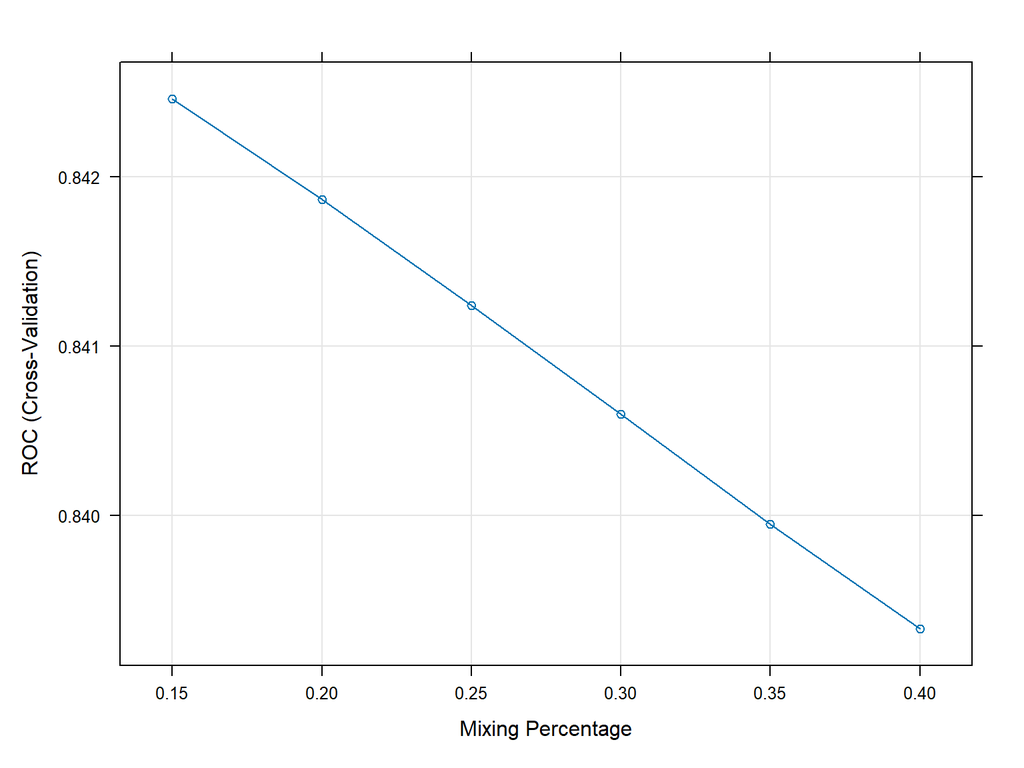

```r
# fit a logistic regression model to the original training data
# log_reg1 <- train(
#   loan_default ~ . + fico_range_avg*last_credit_pull_d_years_since_grouped,
#   data = data_train,
#   method = "glmnet",
#   trControl = ctrl,
#   tuneGrid = expand.grid(
#     alpha = seq(0.15, 0.4, 0.05),
#     lambda = 0.01),      # seq(0.01, 0.11, length = 10)),
#   metric = "ROC",
#   family = "binomial"
# )

# save model as .rds file to save time in knitting
# saveRDS(log_reg1, file = "log_reg1.rds")
# read in .rds file to save time in knitting
log_reg1 <- readRDS("log_reg1.rds")

plot(log_reg1)
```

```r
log_reg1$bestTune
```

|  | alpha | lambda |
| --- | --- | --- |
| 1 | 0.15 | 0.01 |

```r
log_reg1$results
```

|  | alpha | lambda | ROC | Sens | Spec | ROCSD | SensSD | SpecSD |
| --- | --- | --- | --- | --- | --- | --- | --- | --- |
| 1 | 0.15 | 0.01 | 0.8424604 | 0.9612255 | 0.3519734 | 0.002398473 | 0.001572100 | 0.006691620 |
| 2 | 0.20 | 0.01 | 0.8418683 | 0.9622100 | 0.3457743 | 0.002429820 | 0.001573069 | 0.006114824 |
| 3 | 0.25 | 0.01 | 0.8412427 | 0.9631527 | 0.3392321 | 0.002463606 | 0.001558668 | 0.005054049 |
| 4 | 0.30 | 0.01 | 0.8405986 | 0.9639801 | 0.3331617 | 0.002493454 | 0.001560934 | 0.004922405 |
| 5 | 0.35 | 0.01 | 0.8399476 | 0.9644410 | 0.3287001 | 0.002512105 | 0.001423755 | 0.005518212 |
| 6 | 0.40 | 0.01 | 0.8393325 | 0.9651322 | 0.3242171 | 0.002531215 | 0.001394736 | 0.005564387 |

```r
coef(log_reg1$finalModel,log_reg1$bestTune$lambda)
```

```
## 125 x 1 sparse Matrix of class "dgCMatrix"
##                                                                 s=0.01
## (Intercept)                                               2.652649e+00
## loan_amnt                                                 9.517882e-06
## term5_Years                                               4.216351e-01
## int_rate                                                  7.490204e-02
## sub_gradeA2                                              -1.591229e-01
## sub_gradeA3                                              -9.557559e-02
## sub_gradeA4                                              -4.368060e-02
## sub_gradeA5                                              -1.413640e-02
## sub_gradeB1                                              -1.565601e-02
## sub_gradeB2                                              -2.060725e-02
## sub_gradeB3                                              -2.548634e-02
## sub_gradeB4                                               .
## sub_gradeB5                                               .
## sub_gradeC1                                               .
## sub_gradeC2                                               4.149590e-02
## sub_gradeC3                                               6.047662e-02
## sub_gradeC4                                               6.778289e-02
## sub_gradeC5                                               4.144985e-02
## sub_gradeD1                                               7.049563e-02
## sub_gradeD2                                               4.411108e-02
## sub_gradeD3                                               .
## sub_gradeD4                                               5.612257e-02
## sub_gradeD5                                               .
## sub_gradeE1                                               .
## sub_gradeE2                                               5.443886e-02
## sub_gradeE3                                               2.142505e-02
## sub_gradeE4                                               .
## sub_gradeE5                                               .
## sub_gradeF1                                              -5.255303e-03
## sub_gradeF2                                               .
## sub_gradeF3                                               .
## sub_gradeF4                                               .
## sub_gradeF5                                               2.658254e-02
## sub_gradeG1                                              -2.444537e-02
## sub_gradeG2                                               .
## sub_gradeG3                                               .
## sub_gradeG4                                              -7.211913e-02
## sub_gradeG5                                               .
```

[output cut: 72 more lines]

```
## emp_title_groupSales                                      .
## emp_title_groupSelf-Employed                              4.631211e-02
## emp_title_groupTech                                      -5.531611e-02
## emp_title_groupTrades                                     1.424526e-01
## emp_title_groupTransportation                             4.117448e-02
## mort_acc_NA1                                              1.953088e-01
## mort_acc_grouped1                                         .
## mort_acc_grouped2                                         .
## mort_acc_grouped3-4                                      -9.461301e-02
## mort_acc_grouped5+                                       -1.443481e-01
## int_loan_amnt_revol_bal_log                               .
## fico_range_avg:last_credit_pull_d_years_since_grouped7    5.753609e-05
## fico_range_avg:last_credit_pull_d_years_since_grouped8    1.099346e-03
## fico_range_avg:last_credit_pull_d_years_since_grouped9    1.361924e-03
## fico_range_avg:last_credit_pull_d_years_since_grouped10+ -3.554071e-04
```

**We iterated through different sequences of both alpha (starting at 0 to 1 by 0.01, ending with 0.15 to 0.4 by 0.05) and lambda (0.01 to 0.11 by 0.01) to optimize our logistic regression model on ROC. The optimal values of alpha and lambda for the elastic net regularization approach are alpha = 0.15 and lambda = 0.01.**

```r
# predict probabilities on holdout
log_reg1_pred_prob <- predict(log_reg1, data_holdout, type = "prob")[, "Yes"]

# create true labels (1 = Yes, 0 = No)
true_labels <- ifelse(data_holdout$loan_default == "Yes", 1, 0)

# use ROCR to evaluate across thresholds
pred <- ROCR::prediction(log_reg1_pred_prob, true_labels)

# get precision-recall performance
perf <- ROCR::performance(pred, measure = "prec", x.measure = "rec")

# compute AUC
perf_auc <- ROCR::performance(pred, measure = "auc")
auc_log_reg1 <- perf_auc@y.values[[1]]
print(auc_log_reg1)
```

```
## [1] 0.8421884
```

```r
# extract values
precision <- perf@y.values[[1]]
recall <- perf@x.values[[1]]
thresholds <- perf@alpha.values[[1]]

# compute F1
f1 <- 2 * (precision * recall) / (precision + recall)
f1[is.nan(f1)] <- 0

# find best threshold and F1
best_index_log_reg1 <- which.max(f1)
best_thresh_log_reg1 <- thresholds[best_index_log_reg1]
best_f1_log_reg1 <- f1[best_index_log_reg1]

# print results
cat("Best threshold:", best_thresh_log_reg1, "\n")
```

```
## Best threshold: 0.2839947
```

```r
cat("Best F1 score:", best_f1_log_reg1, "\n")
```

```
## Best F1 score: 0.5843829
```

```r
# create final class predictions using best threshold
log_reg1_pred_class <- factor(
  ifelse(log_reg1_pred_prob >= best_thresh_log_reg1, "Yes", "No"),
  levels = c("No", "Yes")
)

# confusion matrix with optimal threshold
cm <- caret::confusionMatrix(log_reg1_pred_class, data_holdout$loan_default, positive = "Yes")
print(cm)
```

```
## Confusion Matrix and Statistics
##
##           Reference
## Prediction    No   Yes
##        No  53628  4980
##        Yes 10035 10556
##
##                Accuracy : 0.8104
##                  95% CI : (0.8077, 0.8131)
##     No Information Rate : 0.8038
##     P-Value [Acc > NIR] : 1.457e-06
##
##                   Kappa : 0.4647
##
##  Mcnemar's Test P-Value : < 2.2e-16
##
##             Sensitivity : 0.6795
##             Specificity : 0.8424
##          Pos Pred Value : 0.5127
##          Neg Pred Value : 0.9150
##              Prevalence : 0.1962
##          Detection Rate : 0.1333
##    Detection Prevalence : 0.2600
##       Balanced Accuracy : 0.7609
##
##        'Positive' Class : Yes
##
```

**After optimizing our logistic regression model on the original training data using an elastic net regularization approach, the metrics of optimal model prediction performance are as follows: AUC = 0.842, threshold = 0.284, F1 = 0.584, accuracy = 0.81, sensitivity = 0.68, and specificity = 0.842.**

### 3.1.2 Downsampled Training Data

Fit a logistic regression on the downsampled training data using elastic net regularization.

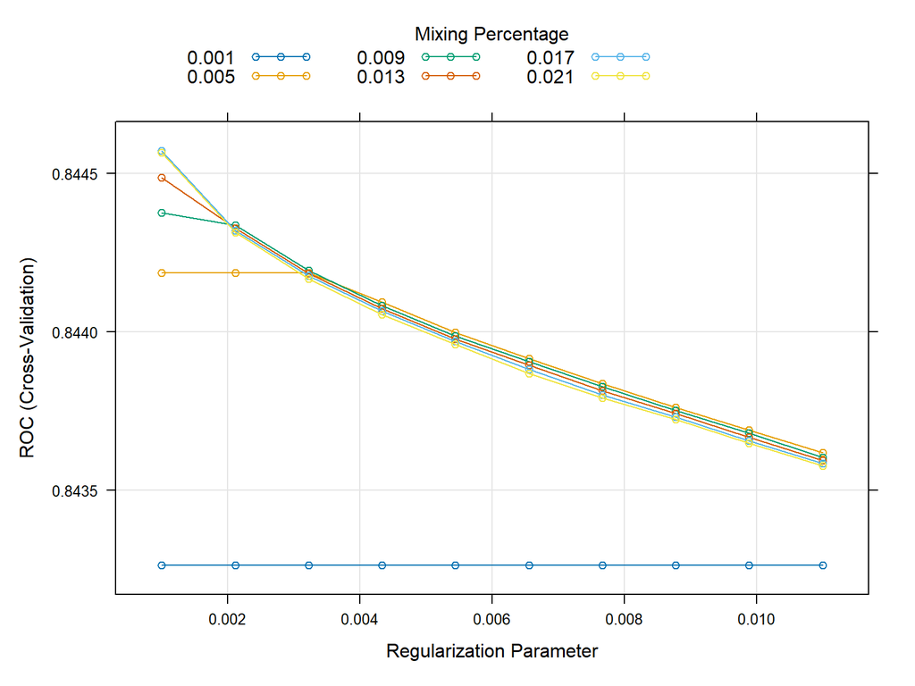

```r
# fit a logistic regression model to the downsampled training data
# log_reg2 <- train(
#   loan_default ~ . + fico_range_avg*last_credit_pull_d_years_since_grouped,
#   data = data_train_ds,
#   method = "glmnet",
#   trControl = ctrl,
#   tuneGrid = expand.grid(
#     alpha = seq(0.001, 0.021, 0.004),
#     lambda = seq(0.001, 0.011, length = 10)),
#   metric = "ROC",
#   family = "binomial"
# )

# save model as .rds file to save time in knitting
# saveRDS(log_reg2, file = "log_reg2.rds")
# read in .rds file to save time in knitting
log_reg2 <- readRDS("log_reg2.rds")

plot(log_reg2)
```

```r
log_reg2$bestTune
```

|  | alpha | lambda |
| --- | --- | --- |
| 41 | 0.017 | 0.001 |

```r
log_reg2$results
```

|  | alpha | lambda | ROC | Sens | Spec | ROCSD | SensSD | SpecSD |
| --- | --- | --- | --- | --- | --- | --- | --- | --- |
| 1 | 0.001 | 0.001000000 | 0.8432628 | 0.7677621 | 0.7760189 | 0.005364728 | 0.009126902 | 0.007462635 |
| 2 | 0.001 | 0.002111111 | 0.8432628 | 0.7677621 | 0.7760189 | 0.005364728 | 0.009126902 | 0.007462635 |
| 3 | 0.001 | 0.003222222 | 0.8432628 | 0.7677621 | 0.7760189 | 0.005364728 | 0.009126902 | 0.007462635 |
| 4 | 0.001 | 0.004333333 | 0.8432628 | 0.7677621 | 0.7760189 | 0.005364728 | 0.009126902 | 0.007462635 |
| 5 | 0.001 | 0.005444444 | 0.8432628 | 0.7677621 | 0.7760189 | 0.005364728 | 0.009126902 | 0.007462635 |
| 6 | 0.001 | 0.006555556 | 0.8432628 | 0.7677621 | 0.7760189 | 0.005364728 | 0.009126902 | 0.007462635 |
| 7 | 0.001 | 0.007666667 | 0.8432628 | 0.7677621 | 0.7760189 | 0.005364728 | 0.009126902 | 0.007462635 |
| 8 | 0.001 | 0.008777778 | 0.8432628 | 0.7677621 | 0.7760189 | 0.005364728 | 0.009126902 | 0.007462635 |
| 9 | 0.001 | 0.009888889 | 0.8432628 | 0.7677621 | 0.7760189 | 0.005364728 | 0.009126902 | 0.007462635 |
| 10 | 0.001 | 0.011000000 | 0.8432628 | 0.7677621 | 0.7760189 | 0.005364728 | 0.009126902 | 0.007462635 |

[output cut: 50 more lines]

```r
coef(log_reg2$finalModel,log_reg2$bestTune$lambda)
```

```
## 125 x 1 sparse Matrix of class "dgCMatrix"
##                                                                s=0.001
## (Intercept)                                               3.923850e+00
## loan_amnt                                                 5.337309e-05
## term5_Years                                               4.730180e-01
## int_rate                                                  5.678635e-02
## sub_gradeA2                                              -1.666893e-02
## sub_gradeA3                                               4.959163e-02
## sub_gradeA4                                               1.602151e-01
## sub_gradeA5                                               2.242824e-01
## sub_gradeB1                                               2.904078e-01
## sub_gradeB2                                               2.717385e-01
## sub_gradeB3                                               2.572969e-01
## sub_gradeB4                                               3.552302e-01
## sub_gradeB5                                               3.478080e-01
## sub_gradeC1                                               4.133428e-01
## sub_gradeC2                                               4.728048e-01
## sub_gradeC3                                               4.938402e-01
## sub_gradeC4                                               5.058402e-01
## sub_gradeC5                                               5.422738e-01
## sub_gradeD1                                               5.580933e-01
## sub_gradeD2                                               5.565459e-01
## sub_gradeD3                                               5.680820e-01
## sub_gradeD4                                               5.534410e-01
## sub_gradeD5                                               4.254356e-01
## sub_gradeE1                                               4.691405e-01
## sub_gradeE2                                               5.890180e-01
## sub_gradeE3                                               5.754976e-01
## sub_gradeE4                                               4.700193e-01
## sub_gradeE5                                               5.714639e-01
## sub_gradeF1                                               4.283654e-01
## sub_gradeF2                                               5.725364e-01
## sub_gradeF3                                               6.200750e-01
## sub_gradeF4                                               7.060260e-01
## sub_gradeF5                                               6.947083e-01
## sub_gradeG1                                               2.576898e-01
## sub_gradeG2                                               3.737202e-01
## sub_gradeG3                                               6.157600e-01
## sub_gradeG4                                               3.140857e-01
## sub_gradeG5                                               6.897158e-01
```

[output cut: 72 more lines]

```
## emp_title_groupSales                                      4.654905e-02
## emp_title_groupSelf-Employed                              1.387936e-01
## emp_title_groupTech                                      -1.118451e-01
## emp_title_groupTrades                                     2.654004e-01
## emp_title_groupTransportation                             7.269985e-02
## mort_acc_NA1                                              1.840814e-01
## mort_acc_grouped1                                         8.696869e-03
## mort_acc_grouped2                                         1.848712e-02
## mort_acc_grouped3-4                                      -8.550606e-02
## mort_acc_grouped5+                                       -1.398600e-01
## int_loan_amnt_revol_bal_log                              -3.977945e-06
## fico_range_avg:last_credit_pull_d_years_since_grouped7   -8.940796e-06
## fico_range_avg:last_credit_pull_d_years_since_grouped8    9.193247e-04
## fico_range_avg:last_credit_pull_d_years_since_grouped9    8.577343e-04
## fico_range_avg:last_credit_pull_d_years_since_grouped10+ -5.679982e-04
```

**We iterated through different sequences of both alpha (starting at 0 to 1 by 0.01, ending with 0.001 to 0.021 by 0.004) and lambda (starting at 0.01 to 0.1 by 0.01, ending with 0.001 to 0.011 by 0.001) to optimize our logistic regression model on ROC. The optimal values of alpha and lambda for the elastic net regularization approach are alpha = 0.017 and lambda = 0.001.**

```r
# predict probabilities on holdout
log_reg2_pred_prob <- predict(log_reg2, data_holdout, type = "prob")[, "Yes"]

# create true labels (1 = Yes, 0 = No)
true_labels <- ifelse(data_holdout$loan_default == "Yes", 1, 0)

# use ROCR to evaluate across thresholds
pred <- ROCR::prediction(log_reg2_pred_prob, true_labels)

# get precision-recall performance
perf <- ROCR::performance(pred, measure = "prec", x.measure = "rec")

# compute AUC
perf_auc <- ROCR::performance(pred, measure = "auc")
auc_log_reg2 <- perf_auc@y.values[[1]]
print(auc_log_reg2)
```

```
## [1] 0.8442602
```

```r
# extract values
precision <- perf@y.values[[1]]
recall <- perf@x.values[[1]]
thresholds <- perf@alpha.values[[1]]

# compute F1
f1 <- 2 * (precision * recall) / (precision + recall)
f1[is.nan(f1)] <- 0

# find best threshold and F1
best_index_log_reg2 <- which.max(f1)
best_thresh_log_reg2 <- thresholds[best_index_log_reg2]
best_f1_log_reg2 <- f1[best_index_log_reg2]

# print results
cat("Best threshold:", best_thresh_log_reg2, "\n")
```

```
## Best threshold: 0.6221087
```

```r
cat("Best F1 score:", best_f1_log_reg2, "\n")
```

```
## Best F1 score: 0.5852761
```

```r
# create final class predictions using best threshold
log_reg2_pred_class <- factor(
  ifelse(log_reg2_pred_prob >= best_thresh_log_reg2, "Yes", "No"),
  levels = c("No", "Yes")
)

# confusion matrix with optimal threshold
cm <- caret::confusionMatrix(log_reg2_pred_class, data_holdout$loan_default, positive = "Yes")
print(cm)
```

```
## Confusion Matrix and Statistics
##
##           Reference
## Prediction    No   Yes
##        No  53833  5042
##        Yes  9830 10494
##
##                Accuracy : 0.8122
##                  95% CI : (0.8095, 0.8149)
##     No Information Rate : 0.8038
##     P-Value [Acc > NIR] : 1.194e-09
##
##                   Kappa : 0.4667
##
##  Mcnemar's Test P-Value : < 2.2e-16
##
##             Sensitivity : 0.6755
##             Specificity : 0.8456
##          Pos Pred Value : 0.5163
##          Neg Pred Value : 0.9144
##              Prevalence : 0.1962
##          Detection Rate : 0.1325
##    Detection Prevalence : 0.2566
##       Balanced Accuracy : 0.7605
##
##        'Positive' Class : Yes
##
```

**After optimizing our logistic regression model on the downsampled training data using an elastic net regularization approach, the metrics of optimal model prediction performance are as follows: AUC = 0.844, threshold = 0.622, F1 = 0.585, accuracy = 0.812, sensitivity = 0.68, and specificity = 0.846.**

### 3.1.3 Dummy-coded Training Data

Fit a logistic regression on the dummy-coded training data using elastic net regularization.

**We attempted to iterate through different sequences of both alpha (0 to 1 by 0.1) and lambda (0.01 to 0.11 by 0.01) on the dummy-coded training data to optimize our logistic regression model on ROC, but after four hours of running, the model still would not fit. Considering our models fit on the downsampled data have worked best previously, we chose to move on from attempting to fit a model on the dummy-coded training data and instead focus on the downsampled training data sets.**

### 3.1.4 Downsampled Dummy-coded Training Data

Fit a logistic regression on the downsampled, dummy-coded training data using elastic net regularization.

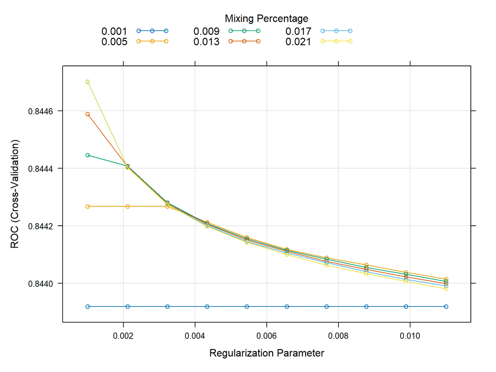

```r
# fit a logistic regression model to the downsampled dummy-coded training data
# log_reg4 <- train(
#   loan_default ~ .,
#   data = data_train_dummy_ds,
#   method = "glmnet",
#   trControl = ctrl,
#   tuneGrid = expand.grid(
#     alpha = seq(0.001, 0.021, 0.004),
#     lambda = seq(0.001, 0.011, length = 10)),
#   metric = "ROC",
#   family = "binomial"
# )

# save model as .rds file to save time in knitting
# saveRDS(log_reg4, file = "log_reg4.rds")
# read in .rds file to save time in knitting
log_reg4 <- readRDS("log_reg4.rds")

plot(log_reg4)
```

```r
log_reg4$bestTune
```

|  | alpha | lambda |
| --- | --- | --- |
| 41 | 0.017 | 0.001 |

```r
log_reg4$results
```

|  | alpha | lambda | ROC | Sens | Spec | ROCSD | SensSD | SpecSD |
| --- | --- | --- | --- | --- | --- | --- | --- | --- |
| 1 | 0.001 | 0.001000000 | 0.8439190 | 0.7684982 | 0.7759974 | 0.003601470 | 0.004818288 | 0.004942357 |
| 2 | 0.001 | 0.002111111 | 0.8439190 | 0.7684982 | 0.7759974 | 0.003601470 | 0.004818288 | 0.004942357 |
| 3 | 0.001 | 0.003222222 | 0.8439190 | 0.7684982 | 0.7759974 | 0.003601470 | 0.004818288 | 0.004942357 |
| 4 | 0.001 | 0.004333333 | 0.8439190 | 0.7684982 | 0.7759974 | 0.003601470 | 0.004818288 | 0.004942357 |
| 5 | 0.001 | 0.005444444 | 0.8439190 | 0.7684982 | 0.7759974 | 0.003601470 | 0.004818288 | 0.004942357 |
| 6 | 0.001 | 0.006555556 | 0.8439190 | 0.7684982 | 0.7759974 | 0.003601470 | 0.004818288 | 0.004942357 |
| 7 | 0.001 | 0.007666667 | 0.8439190 | 0.7684982 | 0.7759974 | 0.003601470 | 0.004818288 | 0.004942357 |
| 8 | 0.001 | 0.008777778 | 0.8439190 | 0.7684982 | 0.7759974 | 0.003601470 | 0.004818288 | 0.004942357 |
| 9 | 0.001 | 0.009888889 | 0.8439190 | 0.7684982 | 0.7759974 | 0.003601470 | 0.004818288 | 0.004942357 |
| 10 | 0.001 | 0.011000000 | 0.8439190 | 0.7684982 | 0.7759974 | 0.003601470 | 0.004818288 | 0.004942357 |

[output cut: 50 more lines]

```r
coef(log_reg4$finalModel,log_reg4$bestTune$lambda)
```

```
## 147 x 1 sparse Matrix of class "dgCMatrix"
##                                                         s=0.001
## (Intercept)                                        9.495193e+00
## loan_amnt                                          5.187519e-05
## int_rate                                           1.767374e-02
## open_acc_cap                                       1.930148e-02
## inq_last_6mths_log                                 1.791083e-01
## annual_inc_log                                    -3.254932e-01
## dti_cap                                            2.421721e-02
## revol_bal_log                                     -3.005422e-02
## revol_util_cap                                     3.346878e-03
## fico_range_avg                                    -5.273747e-03
## int_loan_amnt_revol_bal_log                       -3.914331e-06
## term_3_Years                                      -2.238030e-01
## term_5_Years                                       2.249667e-01
## sub_grade_A1                                      -1.106059e+00
## sub_grade_A2                                      -8.280980e-01
## sub_grade_A3                                      -7.016475e-01
## sub_grade_A4                                      -6.011099e-01
## sub_grade_A5                                      -4.082423e-01
## sub_grade_B1                                      -3.655720e-01
## sub_grade_B2                                      -2.969749e-01
## sub_grade_B3                                      -2.709410e-01
## sub_grade_B4                                      -1.485080e-01
## sub_grade_B5                                      -1.343525e-01
## sub_grade_C1                                      -7.000915e-02
## sub_grade_C2                                      -5.132022e-04
## sub_grade_C3                                       1.057679e-01
## sub_grade_C4                                       9.587764e-02
## sub_grade_C5                                       1.158520e-01
## sub_grade_D1                                       1.555117e-01
## sub_grade_D2                                       2.018118e-01
## sub_grade_D3                                       1.773932e-01
## sub_grade_D4                                       3.217828e-01
## sub_grade_D5                                       2.570352e-01
## sub_grade_E1                                       2.903094e-01
## sub_grade_E2                                       3.633295e-01
## sub_grade_E3                                       4.604151e-01
## sub_grade_E4                                       3.160402e-01
## sub_grade_E5                                       4.393013e-01
```

[output cut: 94 more lines]

```
## emp_title_group_Tech                              -3.998665e-02
## emp_title_group_Trades                             2.849475e-01
## emp_title_group_Transportation                     1.666389e-01
## mort_acc_NA_0                                     -1.022421e-01
## mort_acc_NA_1                                      1.023288e-01
## mort_acc_grouped_0                                 1.707400e-03
## mort_acc_grouped_1                                 1.596563e-02
## mort_acc_grouped_2                                 2.419591e-02
## mort_acc_grouped_3.4                              -6.572954e-02
## mort_acc_grouped_5.                               -1.060028e-01
## fico_x_last_credit_pull_d_years_since_grouped_6    6.621586e-04
## fico_x_last_credit_pull_d_years_since_grouped_7   -8.141489e-04
## fico_x_last_credit_pull_d_years_since_grouped_8    2.915625e-04
## fico_x_last_credit_pull_d_years_since_grouped_9    1.017262e-04
## fico_x_last_credit_pull_d_years_since_grouped_10. -1.257780e-03
```

**We iterated through different sequences of both alpha (starting at 0 to 1 by 0.01, ending with 0.001 to 0.021 by 0.004) and lambda (starting at 0.01 to 0.1 by 0.01, ending with 0.001 to 0.011 by 0.001) to optimize our logistic regression model on ROC. The optimal values of alpha and lambda for the elastic net regularization approach are alpha = 0.017 and lambda = 0.001.**

```r
# predict probabilities on holdout
log_reg4_pred_prob <- predict(log_reg4, data_holdout_dummy, type = "prob")[, "Yes"]

# create true labels (1 = Yes, 0 = No)
true_labels <- ifelse(data_holdout_dummy$loan_default == "Yes", 1, 0)

# use ROCR to evaluate across thresholds
pred <- ROCR::prediction(log_reg4_pred_prob, true_labels)

# get precision-recall performance
perf <- ROCR::performance(pred, measure = "prec", x.measure = "rec")

# compute AUC
perf_auc <- ROCR::performance(pred, measure = "auc")
auc_log_reg4 <- perf_auc@y.values[[1]]
print(auc_log_reg4)
```

```
## [1] 0.8448704
```

```r
# extract values
precision <- perf@y.values[[1]]
recall <- perf@x.values[[1]]
thresholds <- perf@alpha.values[[1]]

# compute F1
f1 <- 2 * (precision * recall) / (precision + recall)
f1[is.nan(f1)] <- 0

# find best threshold and F1
best_index_log_reg4 <- which.max(f1)
best_thresh_log_reg4 <- thresholds[best_index_log_reg4]
best_f1_log_reg4 <- f1[best_index_log_reg4]

# print results
cat("Best threshold:", best_thresh_log_reg4, "\n")
```

```
## Best threshold: 0.6290143
```

```r
cat("Best F1 score:", best_f1_log_reg4, "\n")
```

```
## Best F1 score: 0.5853507
```

```r
# create final class predictions using best threshold
log_reg4_pred_class <- factor(
  ifelse(log_reg4_pred_prob >= best_thresh_log_reg4, "Yes", "No"),
  levels = c("No", "Yes")
)

# confusion matrix with optimal threshold
cm <- caret::confusionMatrix(log_reg4_pred_class, data_holdout_dummy$loan_default, positive = "Yes")
print(cm)
```

```
## Confusion Matrix and Statistics
##
##           Reference
## Prediction    No   Yes
##        No  54072  5139
##        Yes  9591 10397
##
##                Accuracy : 0.814
##                  95% CI : (0.8113, 0.8167)
##     No Information Rate : 0.8038
##     P-Value [Acc > NIR] : 2.004e-13
##
##                   Kappa : 0.4679
##
##  Mcnemar's Test P-Value : < 2.2e-16
##
##             Sensitivity : 0.6692
##             Specificity : 0.8493
##          Pos Pred Value : 0.5202
##          Neg Pred Value : 0.9132
##              Prevalence : 0.1962
##          Detection Rate : 0.1313
##    Detection Prevalence : 0.2524
##       Balanced Accuracy : 0.7593
##
##        'Positive' Class : Yes
##
```

**After optimizing our logistic regression model on the downsampled dummy-coded training data using an elastic net regularization approach, the metrics of optimal model prediction performance are as follows: AUC = 0.845, threshold = 0.629, F1 = 0.585, accuracy = 0.814, sensitivity = 0.669, and specificity = 0.849.**

```r
# stop cluster
stopCluster(cl)
registerDoSEQ()
```

# 4 Model Comparison

```r
# compare models
comparison <- data.frame(
  Model = c("Original", "Downsampled", "Dummy + Downsampled"),
  Best_Threshold = c(best_thresh_log_reg1, best_thresh_log_reg2, best_thresh_log_reg4),
  Best_F1 = c(best_f1_log_reg1, best_f1_log_reg2, best_f1_log_reg4)
)
comparison <- comparison[order(-comparison$Best_F1), ]
print(comparison)
```

```
##                 Model Best_Threshold   Best_F1
## 3 Dummy + Downsampled      0.6290143 0.5853507
## 2         Downsampled      0.6221087 0.5852761
## 1            Original      0.2839947 0.5843829
```

**The model comparison above shows that the logistic regression model fit using the downsampled dummy-coded training data set results in the highest F1 score of 0.5853. All three models result in very similar F1 scores, however, the optimal threshold for the original training data set is much lower than the other two, slightly better models.**

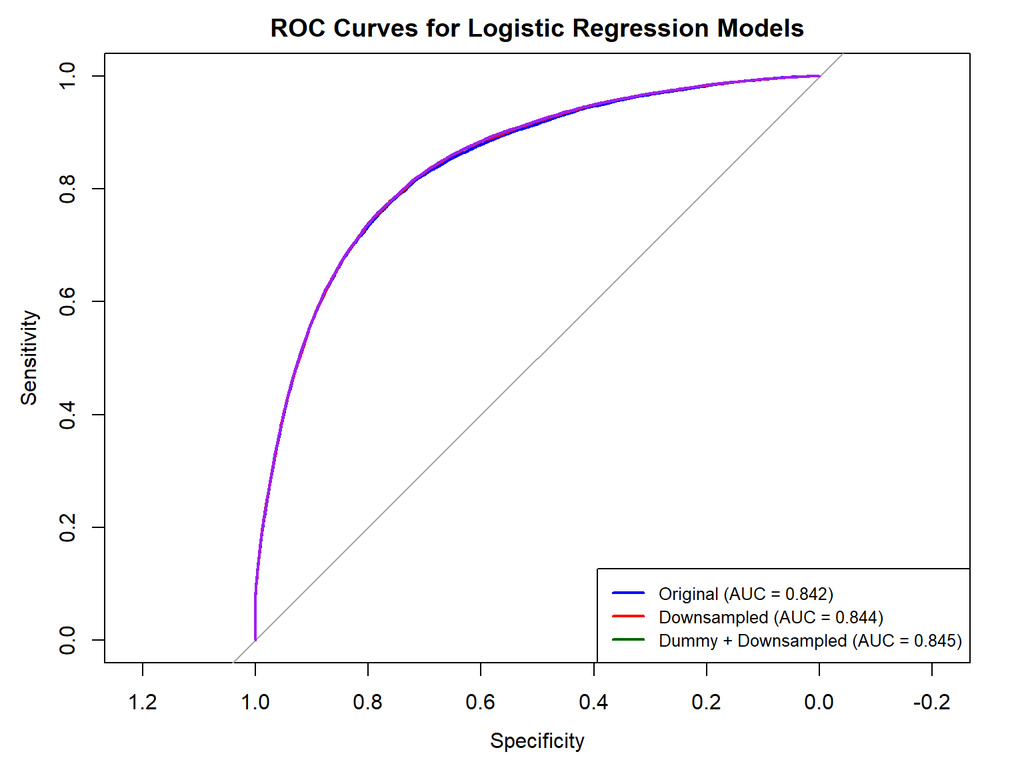

```r
# compare models by plotting ROC curves
roc_og <- pROC::roc(data_holdout$loan_default, predict(log_reg1, data_holdout, type = "prob")[, "Yes"])
roc_ds <- pROC::roc(data_holdout$loan_default, predict(log_reg2, data_holdout, type = "prob")[, "Yes"])
# roc_dummy <- pROC::roc(data_holdout_dummy$loan_default, predict(log_reg3, data_holdout_dummy, type = "prob")[, "Yes"])
roc_dummy_ds <- pROC::roc(data_holdout_dummy$loan_default, predict(log_reg4, data_holdout_dummy, type = "prob")[, "Yes"])

plot(roc_og, col = "blue", lwd = 2, main = "ROC Curves for Logistic Regression Models")
plot(roc_ds, add = TRUE, col = "red", lwd = 2)
# plot(roc_dummy, add = TRUE, col = "darkgreen", lwd = 2)
plot(roc_dummy_ds, add = TRUE, col = "purple", lwd = 2)

legend("bottomright",
       legend = c(
         paste0("Original (AUC = ", round(pROC::auc(roc_og), 3), ")"),
         paste0("Downsampled (AUC = ", round(pROC::auc(roc_ds), 3), ")"),
         # paste0("Dummy (AUC = ", round(pROC::auc(roc_dummy), 3), ")"),
         paste0("Dummy + Downsampled (AUC = ", round(pROC::auc(roc_dummy_ds), 3), ")")
       ),
       col = c("blue", "red", "darkgreen", "purple"),
       lwd = 2,
       cex = 0.8)
```

**The ROC curve comparison above shows almost the exact same curve for all three models. In terms of AUC, the logistic regression model fit using the downsampled dummy-coded training data set has the highest value at 0.845, and the model fit using the downsampled training data set has the second highest value at 0.844.**

# 5 Final Model

**The final logistic regression model chosen is the model trained on the downsampled dummy-coded training data set built using 10-fold cross validation. The model was evaluated on the dummy-coded holdout data set, and an optimal probability threshold of 0.629 was selected to maximize the F1 score at 0.5853507. This threshold-adjusted model represents our final classification rule, optimized for F1 balance between precision and recall.**